# Monte Carlo Markov Chain methods

## Monte Carlo Approximation

There are a variety of ways to calculate integrals. Monte Carlo approximation is a method based on random sampling for calculating integrals and its implementation does not require a deep knowledge of calculus or numerical analysis.

#### Example: Gamma(68, 45)

```r
set.seed(1)
a<-68 ; b<-45
set.seed(1)
theta.support<-seq(0,3,length=100)
theta.sim10<-rgamma(10,a,b)
theta.sim100<-rgamma(100,a,b)
theta.sim1000<-rgamma(1000,a,b)
```

Histograms and kernel density estimates of Monte Carlo approximations to the gamma(68,45) distribution, with the true density in gray.

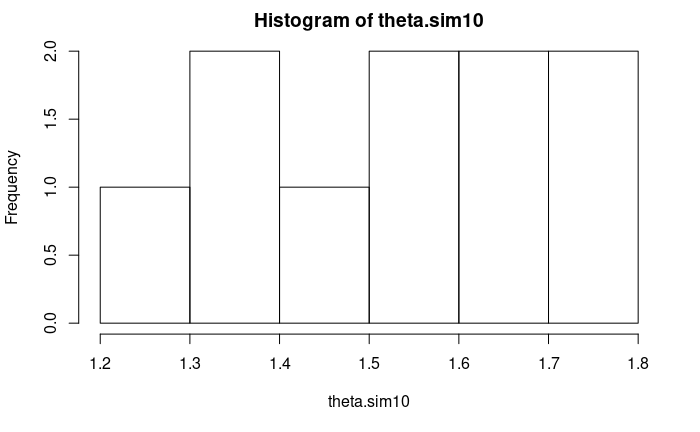

```r
xlim<-c(.75,2.25)
ylim=c(0,2.5)
lty=1
hist(theta.sim10)
```

```r
hist(theta.sim10, prob=T,xlab="", xlim=xlim, ylim=ylim,main="",ylab="")
lines(theta.support,dgamma(theta.support,a,b),col="gray",lwd=2,lty=lty)
```

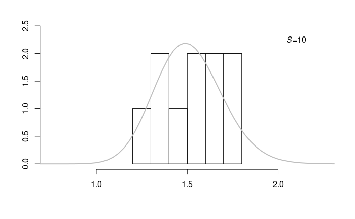

```r
text(2.1,2.25,expression(paste(italic(S),"=10",sep="")))
```

```r
hist( theta.sim100, prob=T,xlim=xlim,ylim=ylim,xlab="",main="" ,ylab="")
lines(theta.support,dgamma(theta.support,a,b),col="gray",lwd=2,lty=lty)
```

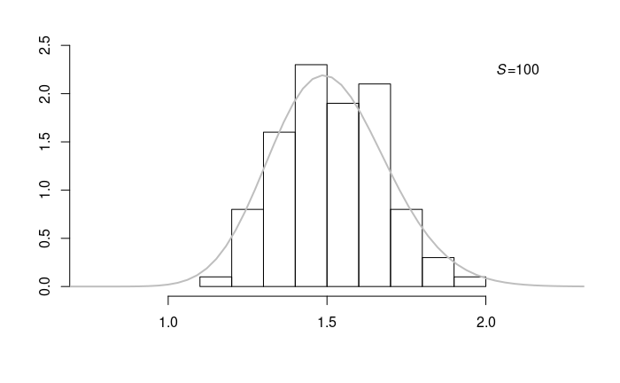

```r
text(2.1,2.25,expression(paste(italic(S),"=100",sep="")))
```

```r
hist( theta.sim1000, prob=T,xlim=xlim,ylim=ylim,xlab="",main="" ,ylab="")
lines(theta.support,dgamma(theta.support,a,b),col="gray",lwd=2,lty=lty)
```

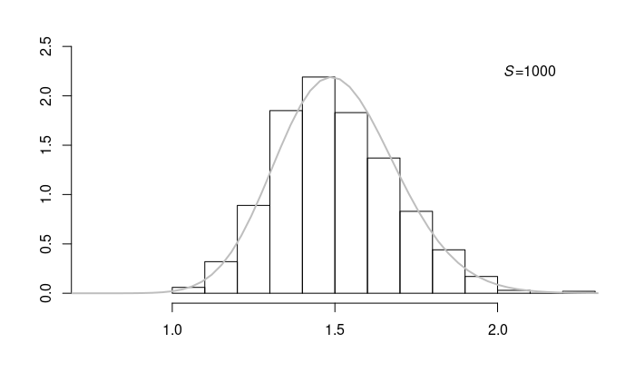

```r
text(2.1,2.25,expression(paste(italic(S),"=1000",sep="")))
```

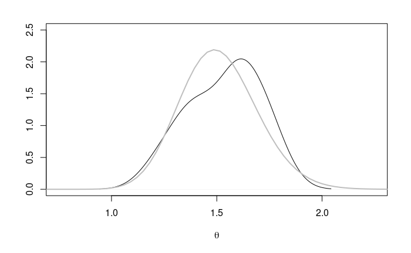

```r
plot(density(theta.sim10),xlim=xlim,ylim=ylim,xlab=expression(theta),main="",ylab="")
lines(theta.support,dgamma(theta.support,a,b),col="gray",lwd=2,lty=lty)
```

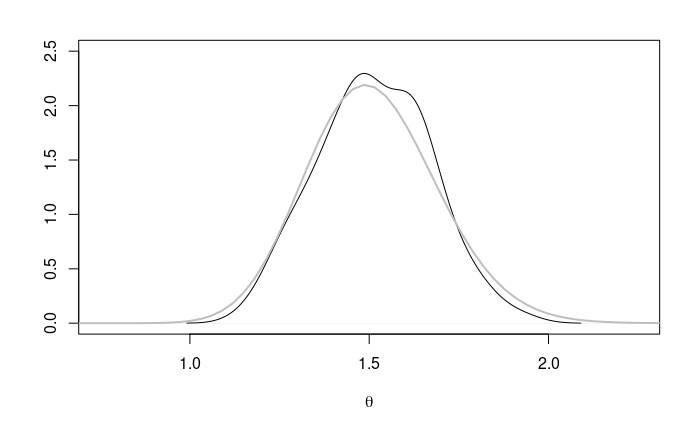

```r
plot(density(theta.sim100),xlim=xlim,ylim=ylim,xlab=expression(theta),main="",ylab="")
lines(theta.support,dgamma(theta.support,a,b),col="gray",lwd=2,lty=lty)
```

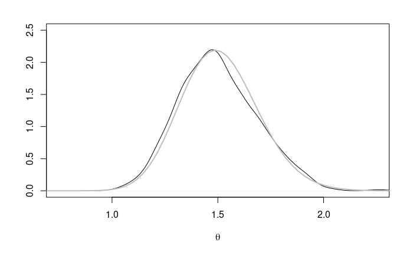

```r
plot(density(theta.sim1000),xlim=xlim,ylim=ylim,xlab=expression(theta),main="",ylab="")
lines(theta.support,dgamma(theta.support,a,b),col="gray",lwd=2,lty=lty)
```

### Example: Poisson-Gamma

Suppose we model $Y_1, \ldots , Y_n|\theta$ as i.i.d. $Poisson(\theta)$, and have a $Gamma(a, b)$ prior distribution for $\theta$. Having observed $Y_1 = y_1, \ldots , Y_n = y_n$, the posterior distribution is $Gamma(a+\sum y_i, b+n)$. We set $(a = 2, b = 1)$ and $(\sum y_i = 66, n = 44)$.

Expectation: The posterior mean is $(a+\sum y_i)/(b+n) = 68/45 = 1.51$.

```r
set.seed(1)
a<-2  ; b<-1
sy<-66; n<-44

theta.sim10<-rgamma(10,a+sy,b+n)
theta.sim100<-rgamma(100,a+sy,b+n)
theta.sim1000<-rgamma(1000,a+sy,b+n)

(a+sy)/(b+n)
```

```
[1] 1.511111
```

```r
mean(theta.sim10)
```

```
[1] 1.532794
```

```r
mean(theta.sim100)
```

```
[1] 1.513947
```

```r
mean(theta.sim1000)
```

```
[1] 1.501015
```

The posterior probability that ${\theta < 1.75}$ can be obtained to a high degree of precision in R with the command $pgamma(1.75,a+sy,b+n)$, which yields 0.8998. Using the simulated values of $\theta$ from above, the corresponding Monte Carlo approximations were:

```r
pgamma(1.75,a+sy,b+n)
```

```
[1] 0.8998286
```

```r
mean( theta.sim10<1.75)
```

```
[1] 0.9
```

```r
mean( theta.sim100<1.75)
```

```
[1] 0.94
```

```r
mean( theta.sim1000<1.75)
```

```
[1] 0.899
```

95% quantile-based confidence region can be obtained with $qgamma(c(.025,.975),a+sy,b+n)$ , giving an interval of (1.173,1.891). Approximate 95% confidence regions can also be obtained from the Monte Carlo samples:

```r
qgamma(c(.025,.975),a+sy,b+n)
```

```
[1] 1.173437 1.890836
```

```r
quantile( theta.sim10, c(.025,.975))
```

```
    2.5%    97.5%
1.260291 1.750068
```

```r
quantile( theta.sim100, c(.025,.975))
```

```
    2.5%    97.5%
1.231646 1.813752
```

```r
quantile( theta.sim1000, c(.025,.975))
```

```
    2.5%    97.5%
1.180194 1.892473
```

We can show the convergence of the Monte Carlo estimates to the correct values graphically, based on cumulative estimates from a sequence of S = 1000 samples from the $Gamma(68,45)$ distribution. Such plots can help indicate when enough Monte Carlo samples have been made. Additionally, Monte Carlo standard errors can be obtained to assess the accuracy of approximations to posterior means:

Estimates of the posterior mean, $Pr(\theta < 1.75|y_1, \ldots, y_n)$ and the 97.5% posterior quantile as a function of the number of Monte Carlo samples. Horizontal gray lines are the true values.

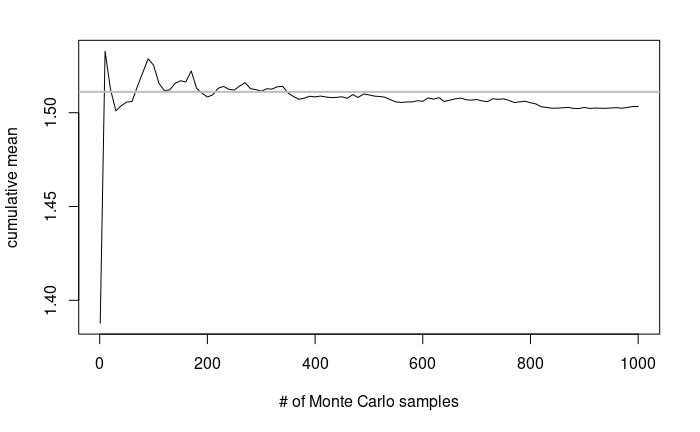

```r
set.seed(1)
a<-2   ; b<-1
sy<-66 ; n<-44

nsim<-1000
theta.sim<-rgamma(nsim,a+sy,b+n)

#cumulative mean

cmean<-cumsum(theta.sim)/(1:nsim)
cvar<- cumsum(theta.sim^2)/(1:nsim) - cmean^2
ccdf<- cumsum(theta.sim<1.75)/ (1:nsim)
cq<-NULL
for(j in 1:nsim){ cq<-c(cq,quantile(theta.sim[1:j],probs=0.975)) }

sseq<- c(1,(1:100)*(nsim/100))
cmean<-cmean[sseq]
cq<-cq[sseq]
ccdf<-ccdf[sseq]

plot(sseq,cmean,type="l",xlab="# of Monte Carlo samples",ylab="cumulative mean",
     col="black")
abline(h= (a+sy)/(b+n),col="gray",lwd=2)
```

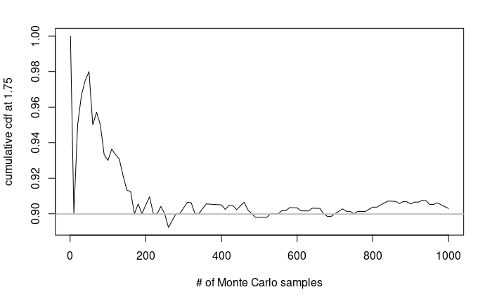

```r
plot(sseq,ccdf,type="l",xlab="# of Monte Carlo samples",ylab="cumulative cdf at 1.75",col="black")
abline(h= pgamma(1.75,a+sy,b+n),col="gray",lwd=2)
```

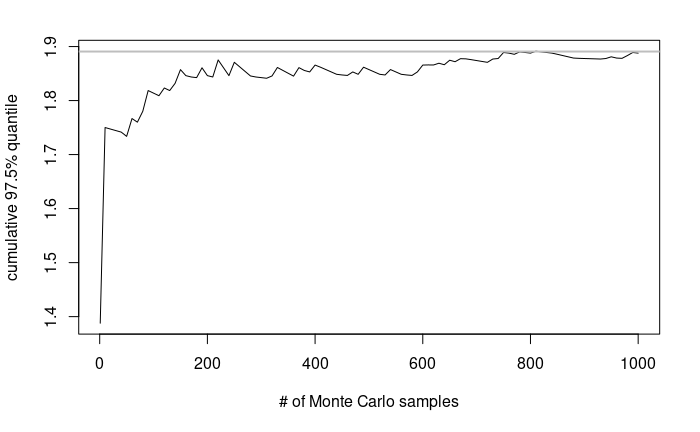

```r
plot(sseq,cq,type="l",xlab="# of Monte Carlo samples",ylab="cumulative 97.5% quantile",col="black")
abline(h= qgamma(.975,a+sy,b+n),col="gray",lwd=2)
```

## MCMC

The purpose of Markov chain Monte Carlo approximation is to obtain a sequence of parameter values $\{\phi^{(1)}, \ldots ,\phi^{(S)}\}$ such that

$$\frac{1}{S} \sum_{s=1}^S g(\phi^{(s)}) \approx \int g(\phi)p(\phi)d\phi$$
for any functions g of interest. In other words, we want the empirical average of $\{g(\phi^{(1)}), \ldots , g(\phi^{(S)})\}$ to approximate the expected value of $g(\phi)$ under a target probability distribution $p(\phi)$ (in Bayesian inference, the target distribution is usually the posterior distribution).

## Gibbs Sampler

For many multiparameter models the joint posterior distribution is nonstandard and difficult to sample from directly. However, it is often the case that it is easy to sample from the full conditional distribution of each parameter. In such cases, posterior approximation can be made with the Gibbs sampler, an iterative algorithm that constructs a dependent sequence of parameter values whose distribution converges to the target joint posterior distribution.

If ${Y_1, \ldots , Y_n|\theta, \sigma^2} \sim i.i.d. Normal(\theta, \sigma^2)$, we know that ${\theta|\sigma^2, y_1, \ldots , y_n} \sim Normal(\mu_n, \tau^2_n)$. In the conjugate case where $\tau^2_0$ was proportional to $\sigma^2$, we showed that $p(\sigma^2|y_1, \ldots , y_n)$ was an inverse-gamma distribution, and that a Monte Carlo sample of ${\theta, \sigma^2}$ from their joint posterior distribution could be obtained by sampling:

1. a value $\sigma^{2(s)}$ from $p(\sigma^2|y_1, \ldots , y_n)$, an inverse-gamma distribution, then
2. a value $\theta^{(s)}$ from $p(\theta|\sigma^{2(s)}, y_1, \ldots , y_n)$, a normal distribution.

### Discrete Approximation

Letting $\tilde{\sigma}^2 = 1/\sigma^2$ be the precision, recall that the posterior distribution of ${\theta, \tilde{\sigma}^2}$ is equal to the joint distribution of ${\theta, \sigma^2, y_1, \ldots , y_n}$, divided by $p(y_1, \ldots, y_n)$, which does not depend on the parameters. The joint distribution is easy to compute as it was built out of standard prior and sampling distributions. A discrete approximation to the posterior distribution makes use of these facts by constructing a posterior distribution over a grid of parameter values, based on relative posterior probabilities. This is done by evaluating $p(\theta, \tilde{\sigma}^2, y_1, \ldots , y_n)$ on a two-dimensional grid of values of ${\theta, \tilde{\sigma}^2}$.

Evaluation of this two-parameter posterior distribution at 100 values of each parameter required a grid of size $100\times 100 = 100^2$. In general, to construct a similarly fine approximation for a p-dimensional posterior distribution we would need a p-dimensional grid containing $100^p$ posterior probabilities. This means that discrete approximations will only be feasible for densities having a small number of parameters.

### Sampling from the conditional distributions - Gibbs Sampling

The distributions $p(\theta|\sigma^2, y_1, \ldots , y_n)$ and $p(\sigma^2|\theta, y_1, \ldots , y_n)$ are called the full conditional distributions of $\theta$ and $\sigma^2$ respectively, as they are each a conditional distribution of a parameter given everything else.

Given a current state of the parameters $\phi^{(s)} = \{\theta^{(s)}, \tilde{\sigma}^{2(s)}\}$, we generate a new state as follows:

1. sample $\theta^{(s+1)} \sim p(\theta|\tilde{\sigma}^{2(s)}, y_1, \ldots , y_n)$;
2. sample $\tilde{\sigma}^{2(s+1)} \sim p(\tilde{\sigma}^{2}|\theta^{(s+1)}, y_1, \ldots , y_n)$;
3. let $\phi^{(s+1)} = \{\theta^{(s+1)}, \tilde{\sigma}^{2(s+1)}\}$.

This algorithm is called the Gibbs sampler, and generates a dependent sequence of our parameters $\{\phi^{(1)},\phi^{(2)}, . . . ,\phi^{(S)}\}$.

```r
mu0<-1.9 ; t20 <-0.95^2 ; s20<-.01 ; nu0<-1
y<-c (1.64 ,1.70 ,1.72 ,1.74 ,1.82 ,1.82 ,1.82 ,1.90 ,2.08)

G<-100 ; H<-100
mean.grid<-seq (1.505 ,2.00 , length=G)
prec.grid<-seq (1.75 ,175 , length=H)
post.grid<-matrix (nrow=G, ncol=H)
for(g in 1:G) {
  for(h in 1:H) {
  post.grid[ g , h]<- dnorm(mean.grid[ g ] , mu0, sqrt( t20 ) ) * dgamma( prec.grid[ h ] , nu0 /2 , s20 *nu0/2 ) * prod (dnorm(y , mean.grid[ g ] ,1/ sqrt( prec.grid[ h ] ) ) )
}}
post.grid<-post.grid /sum( post.grid )

mean.post<- apply(post.grid,1,sum)
par(mfrow=c(1,3))
image( mean.grid,prec.grid,post.grid,col=gray( (10:0)/10 ),
     xlab=expression(theta), ylab=expression(tilde(sigma)^2) )
plot(mean.grid,mean.post, main= "Discrete approximation", type="l",xlab=expression(theta),
 ylab=expression( paste(italic("p("),
     theta,"|",italic(y[1]),"...",italic(y[n]),")",sep="")))
```

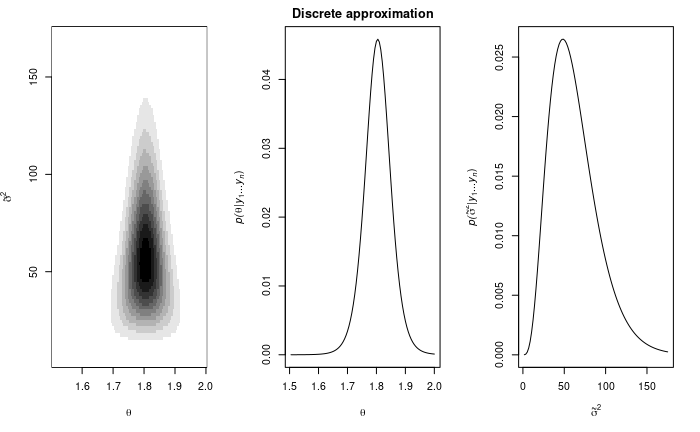

```r
prec.post<-apply(post.grid,2,sum)
plot(prec.grid,prec.post,type="l",xlab=expression(tilde(sigma)^2),
     ylab=expression( paste(italic("p("),
     tilde(sigma)^2,"|",italic(y[1]),"...",italic(y[n]),")",sep="")))
par(mfrow=c(1,1))
```

#### Gibbs sampler

```r
### data
mean.y<-mean( y ) ; var.y<-var (y) ; n<-length (y)
## starting values
set.seed(1)
S<-1000
PHI<-matrix(nrow=S,ncol=2)
PHI[1,]<-phi<-c( mean.y, 1/var.y)

## Gibbs sampling algorithm
for(s in 2:S) {

# generate a new theta value from its full conditional
mun<-  ( mu0/t20 + n*mean.y*phi[2] ) / ( 1/t20 + n*phi[2] )
t2n<- 1/( 1/t20 + n*phi[2] )
phi[1]<-rnorm(1, mun, sqrt(t2n) )

# generate a new sigma^2 value from its full conditional
nun<- nu0+n
s2n<- (nu0*s20 + (n-1)*var.y + n*(mean.y-phi[1])^2 ) /nun
phi[2]<- rgamma(1, nun/2, nun*s2n/2)

PHI[s,]<-phi         }
```

The first 5, 15 and 100 iterations of a Gibbs sampler.

```r
par(mfrow=c(1,3),mar=c(2.75,2.75,.5,.5),mgp=c(1.70,.70,0))
m1<-5
plot( PHI[1:m1,],type="l",xlim=range(PHI[1:100,1]), ylim=range(PHI[1:100,2]),
       lty=1,col="gray",xlab=expression(theta),ylab=expression(tilde(sigma)^2))
text(  PHI[1:m1,1], PHI[1:m1,2], c(1:m1) )
```

```r
m1<-15
plot( PHI[1:m1,],type="l",xlim=range(PHI[1:100,1]), ylim=range(PHI[1:100,2]),
       lty=1,col="gray",xlab=expression(theta),ylab=expression(tilde(sigma)^2))
text(  PHI[1:m1,1], PHI[1:m1,2], c(1:m1) )
```

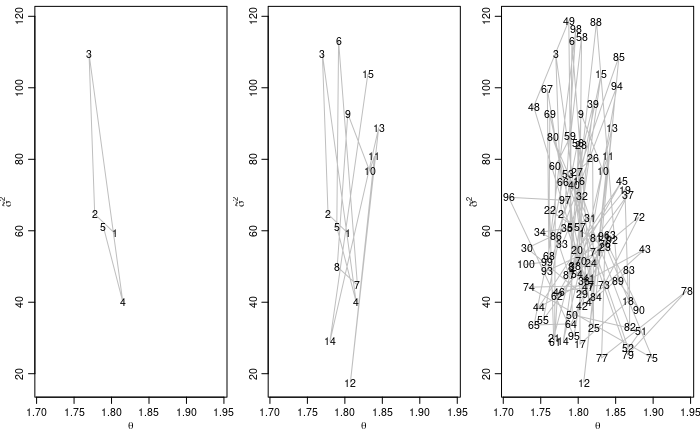

```r
m1<-100
plot( PHI[1:m1,],type="l",xlim=range(PHI[1:100,1]), ylim=range(PHI[1:100,2]),
       lty=1,col="gray",xlab=expression(theta),ylab=expression(tilde(sigma)^2))
text(  PHI[1:m1,1], PHI[1:m1,2], c(1:m1) )
```

Empirical quantiles of our Gibbs samples

```r
#### Posterior quantiles
# CI for the population mean
quantile(PHI[,1],c(.025,.5,.975))
```

```
    2.5%      50%    97.5%
1.707282 1.804348 1.901129
```

```r
# CI for the population precision
quantile(PHI[,2],c(.025,.5, .975))
```

```
     2.5%       50%     97.5%
 17.48020  53.62511 129.20020
```

```r
# CI for population standard deviation
quantile(1/sqrt(PHI[,2]),c(.025,.5, .975))
```

```
      2.5%        50%      97.5%
0.08797701 0.13655763 0.23918408
```

```r
par(mfrow=c(1,3),mar=c(2.75,2.75,.5,.5),mgp=c(1.70,.70,0))
sseq<-1:1000


image( mean.grid,prec.grid,post.grid,col=gray( (10:0)/10 ),
     xlab=expression(theta), ylab=expression(tilde(sigma)^2) ,
     xlim=range(PHI[,1]),ylim=range(PHI[,2]) )
points(PHI[sseq,1],PHI[sseq,2],pch=".",cex=1.25 )
```

```r
plot(density(PHI[,1],adj=2),  xlab=expression(theta),main="",
     xlim=c(1.55,2.05),
 ylab=expression( paste(italic("p("),
     theta,"|",italic(y[1]),"...",italic(y[n]),")",sep="")))
abline(v=quantile(PHI[,1],prob=c(.025,.975)),lwd=2,col="gray")
```

```r
## t-test based confidence interval
n<-length(y) ; ybar<-mean(y) ; s2<-var(y)
ybar+qt( c(.025,.975), n-1) *sqrt(s2/n)
```

```
[1] 1.704583 1.904306
```

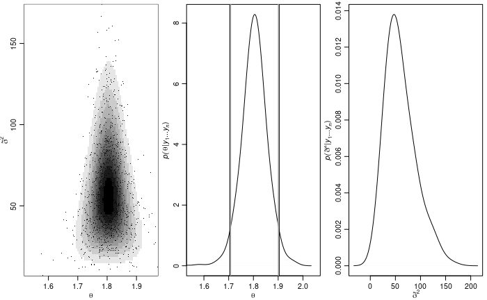

```r
abline( v= ybar+qt( c(.025,.975), n-1) *sqrt(s2/n), col="black",lwd=1)

plot(density(PHI[,2],adj=2), xlab=expression(tilde(sigma)^2),main="",
     ylab=expression( paste(italic("p("),
     tilde(sigma)^2,"|",italic(y[1]),"...",italic(y[n]),")",sep="")))
```

## Metropolis Hastings

When conjugate or semiconjugate prior distributions are used, the posterior distribution can be approximated with the Monte Carlo method or the Gibbs sampler. In situations where a conjugate prior distribution is unavailable or undesirable, the full conditional distributions of the parameters do not have a standard form and the Gibbs sampler cannot be easily used. The Metropolis-Hastings algorithm is a generic method of approximating the posterior distribution corresponding to any combination of prior distribution and sampling model.

Let’s consider a very generic situation where we have a sampling model $Y \sim p(y|\theta)$ and a prior distribution $p(\theta)$. Although in most problems $p(y|\theta)$ and $p(\theta)$ can be calculated for any values of $y$ and $\theta$, $p(\theta|y)=p(\theta)p(y|\theta)/\int p(\theta')p(y|\theta') d\theta'$ is often hard to calculate due to the integral in the denominator. If we were able to sample from $p(\theta|y)$, then we could generate $\theta^{(1)}, \ldots , \theta^{(S)} \sim i.i.d. p(\theta|y)$ and obtain Monte Carlo approximations to posterior quantities, but what if we cannot sample directly from $p(\theta|y)$? We can use a Metropolis Hasting algorithm.

Now we want to generate 10000 iterations of the Metropolis algorithm, starting at $\theta^{(0)} = 0$ and using a normal proposal distribution, $\theta^{(s+1)} \sim Normal (\theta^{(s)}, \delta^2)$ with known variance $\delta^2 = 2$.

```r
#### MH algorithm for one-sample normal problem with

## Setup
s2<-1
t2<-10 ; mu<-5

set.seed(1)
n<-5
y<-round(rnorm(n,10,1),2)

mu.n<-( mean(y)*n/s2 + mu/t2 )/( n/s2+1/t2)
t2.n<-1/(n/s2+1/t2)

## MCMC
s2<-1 ; t2<-10 ; mu<-5
y<-c(9.37, 10.18, 9.16, 11.60, 10.33)
theta<-0 ; delta<-2 ; S<-10000 ; THETA<-NULL ; set.seed(1)

for(s in 1:S)
{

  theta.star<-rnorm(1,theta,sqrt(delta))

  log.r<-( sum(dnorm(y,theta.star,sqrt(s2),log=TRUE)) +
               dnorm(theta.star,mu,sqrt(t2),log=TRUE) )  -
         ( sum(dnorm(y,theta,sqrt(s2),log=TRUE)) +
               dnorm(theta,mu,sqrt(t2),log=TRUE) )

  if(log(runif(1))<log.r) { theta<-theta.star }

  THETA<-c(THETA,theta)

}
```

Results from the Metropolis algorithm for the normal model.

```r
par(mar=c(3,3,1,1),mgp=c(1.75,.75,0))
par(mfrow=c(1,2))

skeep<-seq(10,S,by=10)
plot(skeep,THETA[skeep],type="l",xlab="iteration",ylab=expression(theta))

hist(THETA[-(1:50)],prob=TRUE,main="",xlab=expression(theta),ylab="density")
```

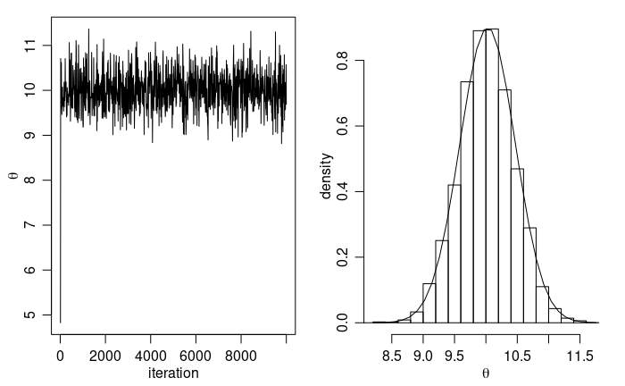

```r
th<-seq(min(THETA),max(THETA),length=100)
lines(th,dnorm(th,mu.n,sqrt(t2.n)) )
```

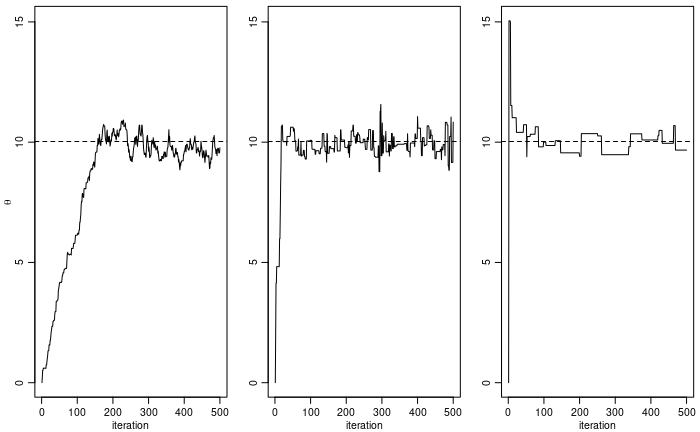

```r
#### MH algorithm with different proposal distributions

ACR<-ACF<-NULL
THETAA<-NULL
for(delta2 in 2^c(-5,-1,1,5,7) ) {
set.seed(1)
THETA<-NULL
S<-10000
theta<-0
acs<-0
delta<-2

for(s in 1:S)
{

  theta.star<-rnorm(1,theta,sqrt(delta2))
  log.r<-sum( dnorm(y,theta.star,sqrt(s2),log=TRUE)-
              dnorm(y,theta,sqrt(s2),log=TRUE)  )  +
      dnorm(theta.star,mu,sqrt(t2),log=TRUE)-dnorm(theta,mu,sqrt(t2),log=TRUE)

  if(log(runif(1))<log.r)  { theta<-theta.star ; acs<-acs+1 }
  THETA<-c(THETA,theta)

}
#plot(THETA[1:1000])

#ACR<-c(ACR,acs/s)
#ACF<-c(ACF,acf(THETA,plot=FALSE)$acf[2]  )
THETAA<-cbind(THETAA,THETA)
}
#plot(ACR,ACF) ; lines(ACR,ACF)

par(mfrow=c(1,3),mar=c(2.75,2.75,.5,.5),mgp=c(1.7,.7,0))
laby<-c(expression(theta),"","","","")

for(k in c(1,3,5)) {
plot(THETAA[1:500,k],type="l",xlab="iteration",ylab=laby[k],
    ylim=range(THETAA) )
abline(h=mu.n,lty=2)
                  }
```